# S&P500 Daily stock Returns

**T. Evgeniou, INSEAD**

**N. Nassuphis, Satrapade**

**D. Spinellis, AUEB**

## Project Description

The project is based on the paper [Regularized Robust Portfolio Estimation](http://www.insead.edu/facultyresearch/research/doc.cfm?did=52770) by T. Evgeniou, M. Pontil, D. Spinellis, R. Swiderski, and N. Nassuphis.

It describes a simple analysis of daily stock returns of S&P 500 stocks.

**Disclaimer:**

```
This project is meant to be an example of how to organize a data analytics case study/project. It is not meant to provide insights for stock data or stock trading. It also does not build on any finance literature (e.g. regarding risk factors such as size, growth, or momentum).
```

## The Data

Ten years (from 2003-01-03 to 2013-04-12) of daily returns of 423 companies which were in the S&P500 index in February 2013. Every row is a day and every column is an individual stock. The data matrix has 2586 rows and 423 columns.

This is the histogram of the daily stock returns across all these stocks during this time period:

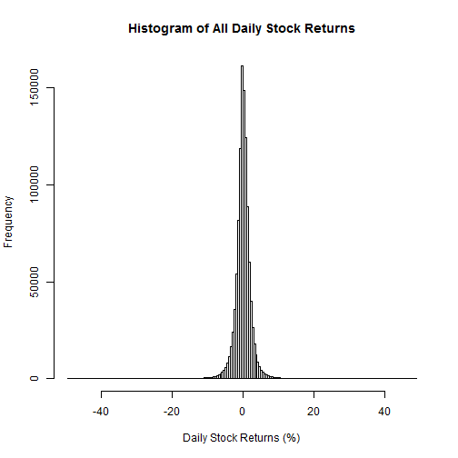

The equal-weight average of these stocks (the “equal weight market”) has performed as follows:

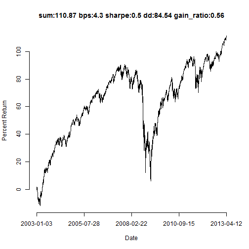

where dd is the maximum drawdown and gain_ratio is the percentage of the days the market had positive returns.

[output not shown]

These are some basic summary statistics about this market's daily returns:

Summary Statistics Daily Market Returns

| V1 | V2 | V3 | V4 | V5 | V6 |
| --- | --- | --- | --- | --- | --- |
| Min. :-10.543 | 1st Qu.: -0.514 | Median : 0.099 | Mean : 0.043 | 3rd Qu.: 0.673 | Max. : 10.948 |

If we select With hindsight the best individual stock in terms of returns, it performs as follows:

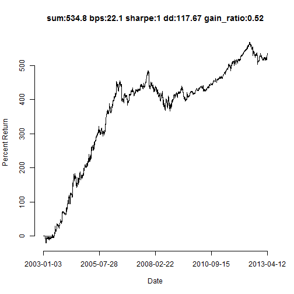

while the worst one is:

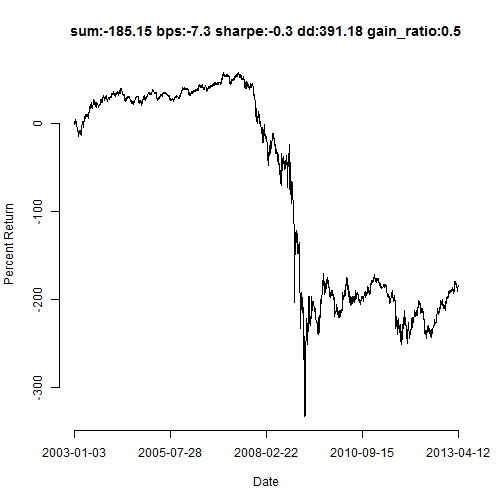

These company tickers are MNST and C, respectively. If we were to select them using their Sharpe, the best and worst stocks would have been AAPL and C, respectively.

## An Analysis

We will build on the basic **mean-reverting** strategy from [The Econometrics of Financial Markets](http://press.princeton.edu/titles/5904.html) by J. Campbell, A. Lo, and C. MacKinlay.

```r
mr_strategy = -sign(shift(market, 1)) * market
names(mr_strategy) <- names(market)
```

which, when applied to the equally weighted market performs as follows:

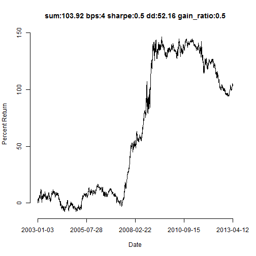

We see the **special period during the financial crisis**.

If we were to implement this *only the days when the previous day the market fell*, this would perform as follows:

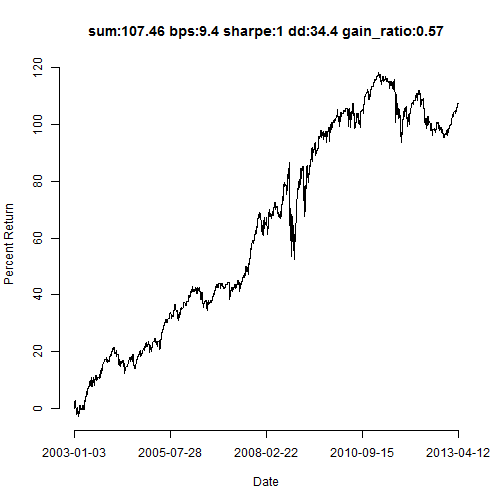

while the days when the previous day the market rose, this performed as follows:

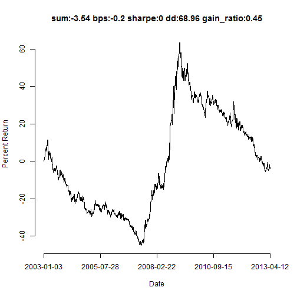

The difference in bevavior is quite visible. Moreover, we can see **different market regimes** during this period.

If we select with hindsight the best individual stock in terms of returns for this simple strategy (**the most mean reverting S&P500 stock the past 10 years**), it performs as follows:

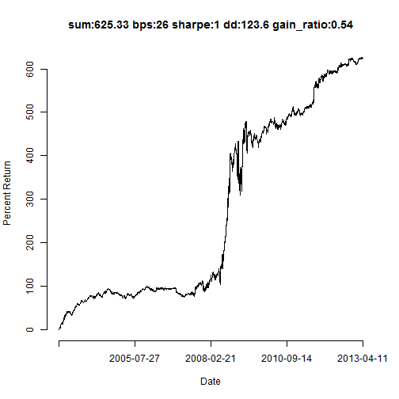

while the worst one (**the least mean reverting S&P500 stock the past 10 years**) is:

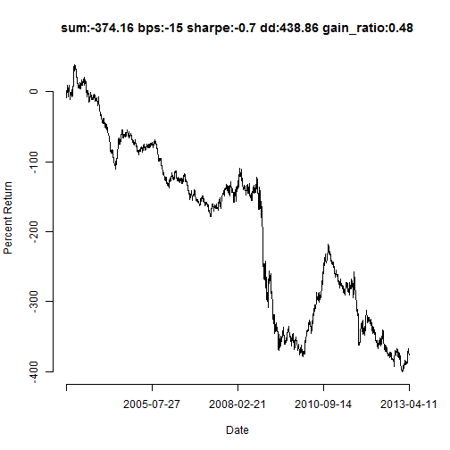

These company tickers are HBAN and MU, respectively. If we were to select them using their Sharpe, the best and worst stocks would have been PCL and F, respectively.

The “market” of the mean-reverting strategies is:

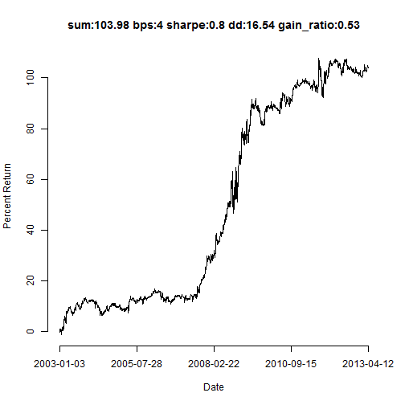

Notice that one could also use the following **momentum** strategy instead:

```r
mom_strategy = sign(shift(market, 1)) * market
names(mom_strategy) <- names(market)
```

which would lead to the exact opposite returns when used for the market. Clearly MU has now the best returns based on this momentum strategy.

If we could separate the stocks into momentum and mean reverting (e.g. for each stock select the one of the two that leads to better returns or Sharpe), the average of those series would be:

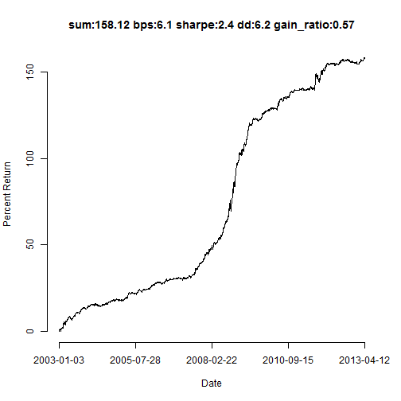

Of course one could do this selection for shorter time windows to achieve even better returns. For example, these are the returns of the last 750 days if we do the selection using only data of these 750 days:

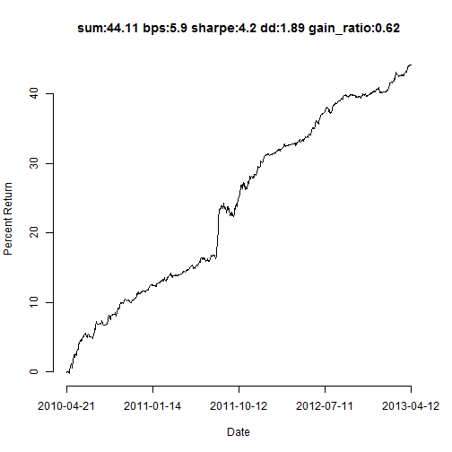

The returns and Sharpe look great, but making this selection between momentum and mean-reversion for each stock without hindsight is of course not practical.

## Risk Factors

Instead of applying these simple mean-reverting and momentum strategies to the actual daily stock returns, one can do so on residuals of the stock returns after regressing individual stocks on (what one could call) *risk factors*.

[output not shown]

We will first perform a simple **Principal Component Analysis** of our data. This will cleate the portfolios with the largest variance. We will then regress each stock on the principal components (using for example linear regression) and estimate the residuals of these regressions. We can then use the exact same mean-reverting and momentum strategies above, but this time for the residuals (which are returns of long-short portfolios, corresponding to the estimated regressions).

Let's first see how many eigenvalues we need to capture a reasonable percentage of the variance in our data. The eigenvalues of this data lead to the following **scree plot**:

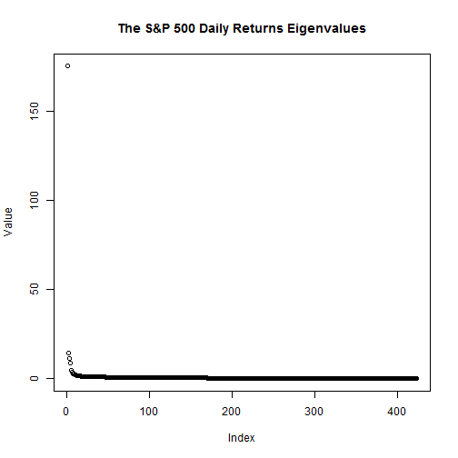

There is one very large eigenvalue: **how would the corresponding largest eigen-portfolio look like?**

As we can also see from the table below, the top 5 eigenvectors capture 50% of the variance in the S&P 500 daily stock data:

Eigenvalues and Variance Explained

|  | eigenvalue | percentage of variance | cumulative percentage of variance |
| --- | --- | --- | --- |
| comp 1 | 175.220 | 41.423 | 41.423 |
| comp 2 | 14.593 | 3.450 | 44.873 |
| comp 3 | 11.487 | 2.716 | 47.589 |
| comp 4 | 8.789 | 2.078 | 49.666 |
| comp 5 | 4.944 | 1.169 | 50.835 |

Let's now see the first principal component of the data. We can plot the returns of the largest PCA component of the S&P 500 data as follows:

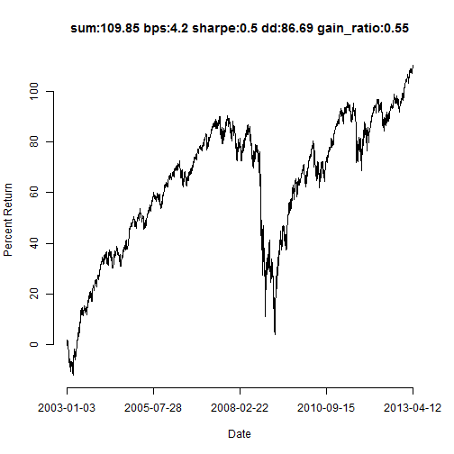

```r
SP500PCA_simple <- eigen(cor(ProjectData))
PCA_first_component = ProjectData %*% norm1(SP500PCA_simple$vectors[, 1])
if (sum(PCA_first_component) < 0) {
    PCA_first_component = -PCA_first_component
    flipped_sign = -1
} else {
    flipped_sign = 1
}
names(PCA_first_component) <- names(market)
pnl_plot(PCA_first_component)
```

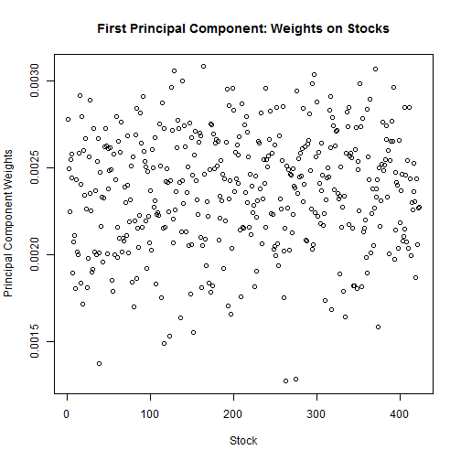

As we see, almost all stocks have the same positive weight 1/423=0.0024.

How about the second component? This is how this one performs:

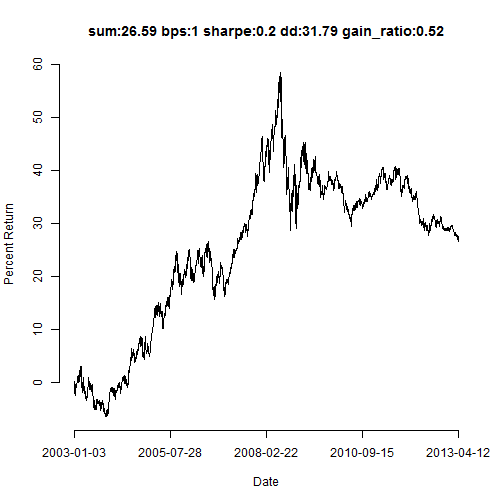

The weights of this component on the stocks are:

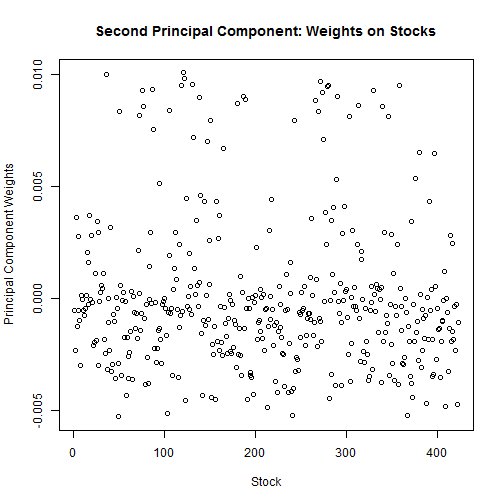

Notice that these are both positive and negative. We can also use a rotation to make the components sparser. These are the top 10 stocks with the largest positive weight: DVN, APA, DO, NOV, EOG, DNR, SWN, NBL, NE, CHK, while these are the top 10 stocks with the largest negative weights: BBT, STI, MTB, CMA, JPM, WFC, ZION, USB, DLTR, FHN.

```
Most of the companies for the second principal component for this time period are from the financial and the energy sectors.
```

Let's now use the first 3 principal components as our **“risk factors”** and estimate the linear regression residuals of all our stocks using these compoments as independent variables. Here is the code tha replaces the original daily returns with the residuals of the stocks when regressed on these factors:

[output not shown]

```r
TheFactors = SP500PCA_simple$vectors[, 1:numb_components_used]
TheFactors = apply(TheFactors, 2, norm1)
TheFactors = apply(TheFactors, 2, function(r) if (sum(ProjectData %*% r) < 0) -r else r)
Factor_series = ProjectData %*% TheFactors
demean_IVs = apply(Factor_series, 2, function(r) r - use_mean_alpha * mean(r))
ProjectData_demean = apply(ProjectData, 2, function(r) r - use_mean_alpha *
    mean(r))
stock_betas = (solve(t(demean_IVs) %*% demean_IVs) %*% t(demean_IVs)) %*% (ProjectData_demean)
stock_alphas = use_mean_alpha * matrix(apply(ProjectData_demean, 2, mean) -
    t(stock_betas) %*% matrix(apply(Factor_series, 2, mean), ncol = 1), nrow = 1)
stock_alphas_matrix = rep(1, nrow(ProjectData)) %*% stock_alphas
# make sure each residuals portfolio invests a total of 1 dollar.
stock_betas_stock = apply(rbind(stock_betas, rep(1, ncol(stock_betas))), 2,
    norm1)
stock_betas = head(stock_betas_stock, -1)  # last one is the stock weight
stock_weight = rep(1, nrow(ProjectData)) %*% tail(stock_betas_stock, 1)
Stock_Residuals = stock_weight * ProjectData - (Factor_series %*% stock_betas +
    stock_alphas_matrix)
```

As before, if we now use the residuals and we select With hindsight the best individual stock (trading its residuals by buying the stock and shorting the risk factor using the estimated regression coefficients, scaled to trade 1 dollar) in terms of returns, it performs as follows:

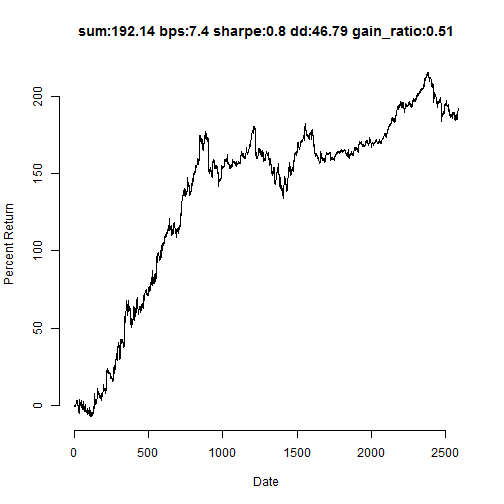

while the worst one is:

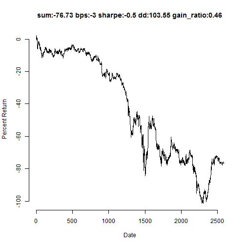

These company tickers are MNST and S, respectively.

```
Note that "trading the residuals" implies that every day we trade the portfolios corresponding to the residuals (with portfolio weights given by the estimated "betas", scaled to invest 1 dollar every day).
```

One can now also explore mean reversion or momentum of the residuals. There are the most mean-reverting and most momentum residuals portfolios:

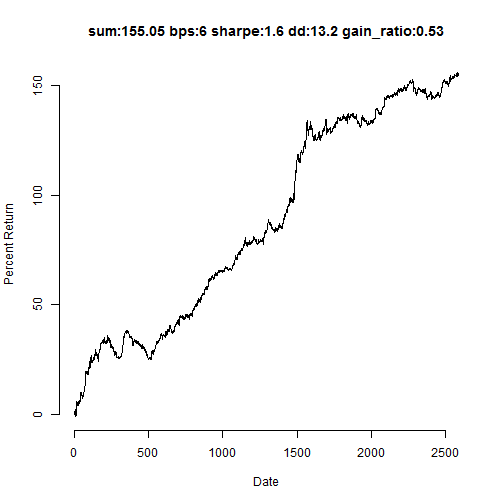

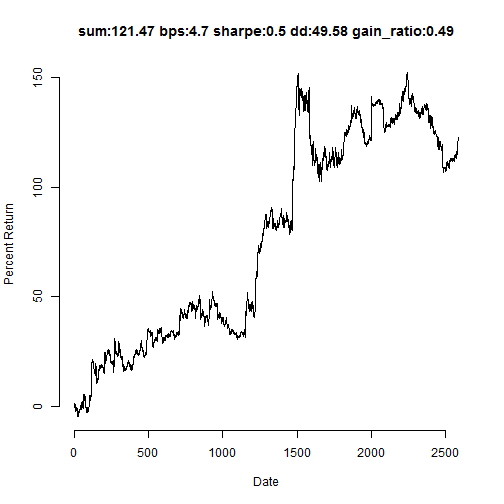

These company tickers are XRX and THC, respectively.

One can also explore the portfolio of individual residual strategies when selecting for each one of them whether to mean revert or not, as we did for the individual stocks above. With hindsight this leads to the following returns:

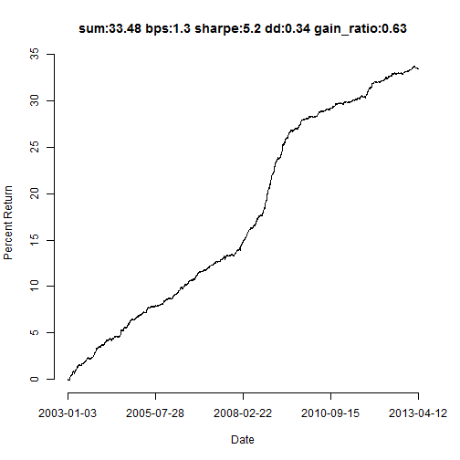

But again, choosing between momentum and mean reversion for each redisual portfolio without hindsight is not practical.

[output not shown]

**As always, one has to be very aware of the signal to noise ratio in the data one explores. This is what “fooled by randomness” can really mean.**

## Some Lessons Learned

- Basic analysis of daily stock returns.
- There appear do be market regimes.
- The “equally weighted market” is the first Principal Component of the daily returns data.
- Example of statistical estimation of, what one could call, “risk factors”.
- Example mean reverting or momentum daily trading strategies.
- It only take a few bits of information with hindsight to get fooled by randomness with this data.